# three way interaction plot template

Original Link: https://tomhouslay.com/2014/03/21/understanding-3-way-interactions-between-continuous-variables/

```r
library(foreign)
library(papaja)
hsb2 <- read.dta("hsb2.dta")
colnames(hsb2)[c(8,7,9,10)] <- c("y","x","z","w")
```

Regress

```r
lm.hsb2 <- lm(y ~ x*z*w, data = hsb2)
summary(lm.hsb2)
```

```
##
## Call:
## lm(formula = y ~ x * z * w, data = hsb2)
##
## Residuals:
##      Min       1Q   Median       3Q      Max
## -20.0432  -4.8576   0.6129   4.0728  17.6322
##
## Coefficients:
##               Estimate Std. Error t value Pr(>|t|)
## (Intercept)  1.665e+02  9.313e+01   1.788   0.0753 .
## x           -3.014e+00  1.803e+00  -1.672   0.0962 .
## z           -3.228e+00  1.926e+00  -1.676   0.0954 .
## w           -2.435e+00  1.757e+00  -1.386   0.1674
## x:z          7.375e-02  3.590e-02   2.054   0.0413 *
## x:w          5.531e-02  3.252e-02   1.701   0.0906 .
## z:w          6.111e-02  3.503e-02   1.745   0.0827 .
## x:z:w       -1.256e-03  6.277e-04  -2.001   0.0468 *
## ---
## Signif. codes:  0 '***' 0.001 '**' 0.01 '*' 0.05 '.' 0.1 ' ' 1
##
## Residual standard error: 6.896 on 192 degrees of freedom
## Multiple R-squared:  0.4893, Adjusted R-squared:  0.4707
## F-statistic: 26.28 on 7 and 192 DF,  p-value: < 2.2e-16
```

The next thing I want to do is to create the slope and intercept values for our 4 combinations of values (high Z + high W, high Z + low W, etc). I use the original data to create high and low values for Z and W (mean plus/minus one standard deviation), then use coefficients from the linear regression to compute the intercepts and slopes:

```r
## High / low for w and z
zH <- mean(hsb2$z) + sd(hsb2$z)
zL <- mean(hsb2$z) - sd(hsb2$z)
wH <- mean(hsb2$w) + sd(hsb2$w)
wL <- mean(hsb2$w) - sd(hsb2$w)

## Get coefficients from regression
coefs.hsb2 <- coef(lm.hsb2)
coef.int <- coefs.hsb2["(Intercept)"]
coef.x <- coefs.hsb2["x"]
coef.z <- coefs.hsb2["z"]
coef.w <- coefs.hsb2["w"]
coef.xz <- coefs.hsb2["x:z"]
coef.xw <- coefs.hsb2["x:w"]
coef.zw <- coefs.hsb2["z:w"]
coef.xzw <- coefs.hsb2["x:z:w"]

## Create slopes
zHwH <- coef.x + zH*coef.xz + wH*coef.xw + zH*wH*coef.xzw
zHwL <- coef.x + zH*coef.xz + wL*coef.xw + zH*wL*coef.xzw
zLwH <- coef.x + zL*coef.xz + wH*coef.xw + zL*wH*coef.xzw
zLwL <- coef.x + zL*coef.xz + wL*coef.xw + zL*wL*coef.xzw

## Create intercepts
i.zHwH <- coef.int + zH*coef.z + wH*coef.w + zH*wH*coef.zw
i.zHwL <- coef.int + zH*coef.z + wL*coef.w + zH*wL*coef.zw
i.zLwH <- coef.int + zL*coef.z + wH*coef.w + zL*wH*coef.zw
i.zLwL <- coef.int + zL*coef.z + wL*coef.w + zL*wL*coef.zw
```

Now, I want to create a data frame that uses these intercepts and slopes to ‘predict’ lines: because I know that the lines are going to be straight, I simply compute the value of Y for the minimum and maximum values of X for each Z:W combination. I’m pretty sure it can be done with far less code than I’ve used here, but there you go:

```r
## a set of values of x
x0 <- seq(min(hsb2$x), max(hsb2$x), length.out = 2)

df.HH <- data.frame(x0 = x0)
df.HH$y0 <- i.zHwH + df.HH$x0*zHwH
df.HH$type <- rep("zHwH", nrow(df.HH))

df.HL <- data.frame(x0 = x0)
df.HL$y0 <- i.zHwL + df.HL$x0*zHwL
df.HL$type <- rep("zHwL", nrow(df.HL))

df.LH <- data.frame(x0 = x0)
df.LH$y0 <- i.zLwH + df.LH$x0*zLwH
df.LH$type <- rep("zLwH", nrow(df.LH))

df.LL <- data.frame(x0 = x0)
df.LL$y0 <- i.zLwL + df.LL$x0*zLwL
df.LL$type <- rep("zLwL", nrow(df.LL))

## Create final data frame
df.pred <- rbind(df.HH, df.HL, df.LH, df.LL)

## Remove unnecessary data frames
rm(df.HH, df.HL, df.LH, df.LL)
```

Now, it’s time to plot the data! I’ve used ggplot2, and specified different colours and line types for each of our 4 combinations: red denotes high Z-value, and solid line denotes high W-value. I’ve also plotted the original data over the top:

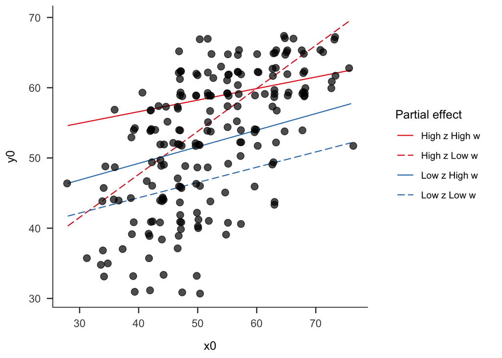

```r
## Call library
library(ggplot2)

## Convert 'type' to factor
df.pred$type <- factor(df.pred$type)

## Draw plot
ggplot(df.pred, aes(x = x0,
                    y = y0)) +
  geom_line(aes(colour = type,
                linetype = type)) +
  geom_jitter(data = hsb2,
            aes(x = x,
                y = y),
             size = 3,
             alpha = 0.7) +
  theme(panel.background = element_rect(fill="white")) +
  theme(legend.key = element_blank()) +
  theme(text = element_text(size = 15)) +
theme_apa() +
  scale_colour_manual(name = "Partial effect",
                      labels = c("High z High w",
                                 "High z Low w",
                                 "Low z High w",
                                 "Low z Low w"),
                      values = c("#E41A1C",
                                 "#E41A1C",
                                 "#377EB8",
                                 "#377EB8")) +
  scale_linetype_manual(name = "Partial effect",
                     labels = c("High z High w",
                                "High z Low w",
                                "Low z High w",
                                "Low z Low w"),
                     values = c("solid",
                                "longdash",
                                "solid",
                                "longdash"))
```